# How has the Brazilian Amazon been constructed as a problem? The economy, the environment, the people, and the nation in the presidential speeches since 1985

Livio Silva-Muller

Henrique Sposito[^1]

May 2022

Abstract

The Amazon Rainforest is one of the most important ecosystems in the world, and most of this biome is located in Brazil. Albeit the importance of understanding the relationship between the social construction of the Amazon and its effects on environmental outcomes, we lack empirical accounts of how the Brazilian Amazon has been constructed as a problem in discourses over time, by geographical location, and between, or within, governments. Discursive problem-construction within democracies legitimize ways of thinking and acting towards the environment while affecting decisions to deforest, or not, at the local level. Building on Hirschman’s conceptualization of chosen problems (1963), we propose a framework to investigate how the Brazilian Amazon has been constructed as a problem in political discourse. Combining hand-coding and supervised machine learning, we classify statements about the Amazon forest or region in 6130 official presidential speeches since 1985. We find that, first, international environmental events appear to drive presidents to speak more about the Amazon. Second, while the Amazon as a problem of economic integration dominated discourses from 1985 to the mid-2000s, environmental conservation and social development constructions briefly surpasses economic integration from 2010 to 2015. Constructing the Amazon as an issue of sovereignty also became more pertinent from 2010 onwards. Finally, using a multinomial regression model, we find that presidents are more likely to construct the Amazon as a problem of environmental conservation, than economic integration or social development, as presidents move away from the Amazon region.

# 1 Introduction

We need to protect the Amazon from foreign interests. We need to exploit the Amazon’s natural resources. We need to provide better living standards for the people in the Amazon. We need to preserve the Amazon as a standing ecosystem. Historically, the Brazilian federal government proposed diverse constructions of the Amazon as a region, forest, or peoples. Each of these constructions contain an implicit assumption of what needs to be solved, or in other words, it represents the Amazon as a particular problem. These specific problems touch on shared imaginaries of the Amazon as part of the larger socio-cultural history of the country as, for example, in relation to issues of national sovereignty, economic integration, social development, or environmental conservation.

Different governments along Brazilian history have been described as proponents of a specific view of the Amazon (Drummond & Barros-Platiau 2016; Padua 2012; Franchini & Viola 2019; Capobianco 2019; Pereira & Viola 2021). For example, while the military dictatorship is associated with both national sovereignty and then economic integration, President Sarney and President Lula are often tied to environmental conservation. However, governments are usually represented monolithically, advancing a view that specific governments see the Amazon as an instance of one specific problem. Albeit the current calls to understand the environment as a social-cultural construction and to identify the effect of culture on environmental outcomes (Waroux et al. 2021), we lack empirical accounts of how the Brazilian Amazon has been constructed as a problem in discourses over time, by geographical location, and between and within governments.

In this article, we investigate how the Brazilian Amazon has been constructed as a problem in political discourses. Building on Hirschman’s concept of chosen problems (1963) and Bacchi’s concept of problem-representation in policy (2009), we propose a framework to identify problem-constructions in political discourses. Although problem-construction takes place in a series of instances, we analyze the case of discourses by Brazilian presidents since 1985. We opt for presidential speeches for two reasons. First, presidential discourses have the power to introduce and justify public policy, as well as shape its perception to broad audiences (Zarefsky 2004). It legitimizes ways of thinking about the Amazon. In turn, policy perception is key for policy adoption and implementation (Alesina and Giuliano 2009; López et al. 2020). This is especially pertinent as deforestation rates in Brazil are associated with expectations from government, generated from material and discursive governmental practices (Assunção, Gandour, and Rocha 2015; Capobianco 2019, 2021), and are a crucial factor in decisions to deforest at the ground (Campbell 2015). Second, we argue that presidents can employ specific problem-constructions that build objects as specific problems depending on where they are. Presidential discourses take place in different sites, from launching a new bridge in a small municipality in the middle of the Amazon to a keynote speech in a business association in São Paulo or at the UN general assembly in New York. Working with presidential discourses allows us to identify this variation in meaningful ways and better how the Amazon is socially constructed.

To investigate how the Brazilian Amazon has been constructed as a problem in political discourses, we create a dataset containing 6130 official presidential speeches by all Brazilian presidents since 1985. We subset the dataset by identifying Amazonian related statements within these speeches. We find that 2014 sections in these discourses refer to the Amazon at least once. We then develop a codebook grounded on Amazonian historiography to code how each of these statements constructs the Amazon as a particular problem. We use this codebook to manually code a randomly selected training set of the Amazonian related statements. We train a supervised machine-learning model in the hand-coded set and automatically label the remaining set of Amazonian statements. We then conduct a descriptive and inferential analysis of this data, tying our findings to endogenous and exogenous events related to deforestation.

We find that, first, international environmental events appear to drive presidents to speak more about the Amazon. Second, while the Amazon as a problem of economic integration dominated discourses from 1985 to the mid-2000s, environmental conservation and social development constructions briefly surpasses economic integration from 2010 to 2015. Constructing the Amazon as an issue of sovereignty also became more pertinent from 2010 onwards. Finally, using a multinomial regression model, we find that presidents are more likely to construct the Amazon as a problem of environmental conservation, than economic integration or social development, as presidents move away from the Amazon region.

# 2 Conceptual framework and contribution

## 2.1 Chosen problems, presidential discourse, and policy issues

Governments often have a choice in how they construct problems and what policy solutions they implement. In “Journey towards Progress”, Hirschman (1963) draws a conceptual distinction between pressing problems (pressured from outside parties to the government) and chosen problems (chosen by the government at their own discretion). Pressing problems can be either privileged or neglected, depending on the degree of pressure exercised by the interested groups. Chosen problems are those governments select at their discretion. Problems can change from pressing to chosen across time and in space as a function of (a) solutions becoming available, (b) a change of level of government control in society, or (c) a shift of interests from top policymakers (Hirschman 1963, 388–91). As Bacchi argues, though, policies have a cultural dimension as “it takes shape within specific historical and national or international contexts”. (2009, 10). The existence or proposal of a policy implies that there is a (public) problem that needs (governmental) action to be fixed. The alleged problem is not always explicitly stated in policy. Hirschman exemplifies chosen problems with the case of the construction of Brasilia (1975, 388). But building Brasilia can solve a problem of regional inequality, a problem of a dormant economy without state investment, a problem of political representation, or all three. It is up to the discretion of the government to highlight or not the implicit problem a policy solves.

Governments can choose to emphasize (or not) one or more implicit problems that a policy solves depending on which interest group they are in communication with. Relative to how the policy is represented to be, it can be a solution of problems that are considered pressing or not for different groups and it is up to the discretion of the political actor to construct a particular problem in a particular way given context. Putnam’s (1988) seminal article on the two-level game can help us make sense of this variation. The author argues that the outcomes of international negotiations lie within the overlap between the pressure of domestic groups and international groups. Taking the example of the 2012 Forest Code and the Amazon, President Dilma could emphasize its rural cadaster for environmentalists at the Paris Summit, or the amnesty for deforestation for agricultural elites. The same policy, then, can solve the problem of environmental conservation as well as economic integration.

This variation in problem-construction suggests that governments are more diverse in their positions as the literature suggests. Several scholars describe federal governments’ as proponents of specific policies for the Amazon Forest and region, using the vocabulary of policy cycles, periods, or phases (see Drummond & Barros-Platiau 2016; Padua 2012; Franchini & Viola 2019; Capobianco 2019; Pereira & Viola 2021). In this literature, the 1964 military dictatorship is associated with securing national sovereignty in the region by populating it and integrating it to the national economy (Drummond & Platiau 2016). The governments from the late 1980s up to 2009, are more associated with environmental conservation. The presidencies of Dilma and Temer are connected to the decline of environmental policies, while Bolsonaro to the complete dismantling of environmental policies. While these works are important to understand how different governments acted towards the Amazon, the classification of specific governments into periods or policy cycles represents them as monolithic: they associate specific governments to one specific view of the Amazon. The presidency of Lula, often associated with environmental conservation because we saw an unprecedented decrease in deforestation. At the same time, during his terms governmental credits to agricultural expansion and the cattle industry surpassed BRL 578 billion (Capobianco, 2021, 106). This sum is about 20 times more than the budget of the Ministry of the Environment for this entire period. There is more variation within governments than the literature suggests.

An interesting site to study the relationship between varied problem-construction and policy issues is presidential speeches as they legitimize ways of thinking about an issue and. While the relationship between presidential speeches and policy is not causal (Lawrence 2004), they have the power to introduce and justify public policy, as well as shape its perception to broad audiences (Zarefsky 2004). Even if presidential discourse might not persuade public opinion regarding a proposed solution for a problem (Eshbaugh-Soha 2010; Rottinghaus 2009; Krebs and Jackson 2007), they direct the range of what is included in national debates (Druckman and Holmes 2004). As presidents speak in varied locations to varied audiences, it is very likely that they chose to frame similar issues differently.

The possibility of different problem-constructions at the level of presidential speeches has important consequences for democracy. If presidents can promote different problem-constructions in different places, it is important to understand to what extent the implemented agenda correlates with their local, federal, or international problem-constructions. Pacheco (2019) proposes that we see the Amazon frontier as a key analytic category to understand the Brazilian state and democracy. Specifically, the author states that the natural richness of the region has been instrumentally transformed in political support through resource exploration by different governments over the last centuries. The costs for said economic benefits are the livelihoods of indigenous and traditional populations and the ecosystems they reside in. Political stability, thus, can be seen as a product of the trade-off between both. Policies during the military dictatorship were strongly geared toward integrating the Amazon into the national territory and international economy. These were times when deforestation increased, but political stability was achieved as those bearing the costs of said deforestation were being targeted. Generally high levels of violence in the region, epitomized in the assassination of Chico Mendes, serve as evidence for that (Hecht and Cockburn 1990). With the return of democracy in the 1980s, violence could not be used at the same extent as before and policies had to respond to growing environmental concern.

Relatedly, the possibility of different problem-constructions has consequences for environmental outcomes as well. When Brazilian presidents speak about the Amazon it not only makes headlines, nationally and internationally (Brice and Smith 2021; Harris 2021; Miranda 2021), but also incites responses, shapes expectations, and feeds into the behavior of many actors involved in the Amazon. Deforestation rates in Brazil are more responsive to the government’s environmental policy than exogenous factors as market fluctuations (Assunção, Gandour, and Rocha 2015; Capobianco 2019, 2021). Ethnographic research has also shown that policy expectations, generated from material and discursive governmental practices, are a crucial factor in decisions to deforest at the ground (Campbell 2015).

The connection between presidential discourse and the environment has been studied in the case of the United States but remains conceptually underdeveloped. Calderwood (2019), for instance, examines 2919 mentions of climate change in American official presidential speeches since 1989. Among various findings, one that stands out is that American presidents frequently side-step the environmental aspects of climate change. He also identifies a shift from economic to security framing of climate issues, side-lining its environmental aspects. Calderwood (2020) also tests the effect of geographic location and type of communication regarding climate change. Building prominently on Putnam (1988), he hypothesizes that presidents are more likely to mention climate change in foreign locations, and that location influences the specific discursive approach and tone they adopt. The author finds evidence in support of his hypothesis, suggesting American presidential discourse at the top on global warming changes based on location. Elsewhere, Bevitori (2015) investigates how the ‘environment’ has been constructed in American presidential discourse since 1960 using a more automated approach. The author finds that mentions of the environment are typically co-selected with the pronoun ‘our’, as well as with ‘economy’, ‘clean’, and ‘preserve’. These studies corroborate the possibilities of variation depending on the audience, but we are yet to tie vocabulary to specific problem-constructions based on wider shared meanings of environment and climate change. While these findings are US specific, they indicate that presidents raise different points about the environment at local, national, or international settings, depending on who they assume their audience is at that specific instance. Nevertheless, as Bacchi (2009), we argue that problem-constructions touch on shared meanings about the region that are available to the speaker as part of larger social-cultural history. Mentions to the lexicon as ‘environment’, ‘preserve’, or ‘climate change’ should be tied to the larger meaning of policies in the United States and elsewhere.

On the other hand, there is also an empirical gap in terms of how the Amazon has been constructed as a problem along time and geographic location. While governmental discourses in Brazil have been studied for topics such as inflation or race relations, we only find one systematic analysis of Amazonian discourse. Barros (2020) investigates Amazonian discourse in the Brazilian Congress with the objective of identifying the arguments put forth by congressmen. The main finding is that the economic value of the Amazon for the cattle industry is the most salient narrative, leading the author to conclude there is a mismatch between the international debate (which focuses on preservation) and the national debate (which focuses on economic development).

We propose a conceptual framework that accepts the possibility of varied problem-construction for the same policy issue and connects it to presidential speeches. Governments choose what problems to solve and what policies to implement. The same policies can be represented as solving different problems implying a degree of social construction (Bacchi 2009). Governments can choose to emphasize or not one or more implicit problems that a policy solves depending on which interest group they are in communication with. The variation in problem-construction suggests that Brazilian governments are more diverse in their positions as the literature suggests. An interesting site to study the relationship between varied problem-construction and policy is presidential speeches as they legitimize ways of thinking about an issue, matter for democracy, and for environmental outcomes. As presidents speak in different places and to different audiences, it is an empirical site prone to identify variation.

## 2.2 Problem-construction in Amazonian historiography

To identify possible problem-constructions and their connection to the wider socio-cultural history of the country, we build on Amazonian historiography. We understand Amazonian historiography as the body of research by social and environmental scientists that tells the story of diverse policies adopted to solve problems in the region.

### National Sovereignty

In The Fate of the Forest: Developers, Destroyers, and Defenders of the Amazon, Hecht and Cockburn write that all over the world tropical forests are destroyed, but “what imbues the case of the Amazon with such passion is the symbolic content of the dreams it ignites” (1990, 1). These dreams of fortunes to be found in the Amazon are composed of the imaginaries of bandeirantes from the southeast of Brazil and colonizers from everywhere else. It rendered the territory the venue for aspiration and the object of an intense scramble in the subsequent centuries, defined as “a (…) form of nation building (…)” (Hecht and Cockburn 1990, preface). The Portuguese empire and subsequently the Brazilian monarchy were concerned with establishing their territory. In the process of securing Amazonian borders, Brazil thwarted “the imperial ambitions of France, Britain, the United States, Belgium, Bolivia, and Peru” (Hecht 2013, 8), and when the dust settled and the scramble was over, half of the Amazon emerged Brazilian. While Brazilian military diplomacy was very successful, the process did not come without its traumas. A significant experience was the negotiations with Bolivia in 1902 to secure the Amazonian state of Acre, during which they found out about American attempts to trick Brazil (Hecht and Cockburn 1990). This case was still part of the memory of the generals who led the country during the military dictatorship of 1964 and wanted to protect Brazil’s sovereignty over the Amazon from the communist threat during the Cold War (Garfield 2013).

As we move from a world where non-state actors gain importance in environmental governance and international politics generally (Silva-Muller and Faul 2022; Andonova 2014; Westerwinter 2021), the sovereignty problem becomes more varied. Multiple non-state actors (NGOs, foundations, IOs, and so on) join the conversation about Amazonian policies more substantially as the military dictatorship starts to end (Hochstetler 2021; Capobianco 2019; Franchini and Viola 2019). Threads to national sovereignty, consequently, can be interpreted as coming from a different set of actors than before. Allegedly false claims about the Brazilian Amazon in international and domestic fora, for instance, are often tied to strategies of ‘internationalizing’ the Amazon. This might come both from foreign actors as well as domestic non-state actors. The sovereignty problem-construction advances the view that the Brazilian Amazon belongs to Brazil while any foreign or non-state presence in the region is part of a broad strategy to take the region. The policy solutions to the issue of sovereignty, included the monitoring of the borders, strict regimes related to entry in the region, assertions of ownership nationally and internationally, and combating alleged disinformation from actors perceived as a threat.

### Economic Integration

The Vargas dictatorship (1937-46) and the military dictatorship (1964-89) took over the task of modernizing the Amazon. In 1966, the Brazilian Military launched Operation Amazon, a policy to modernize the region based on a set of assumptions (Acker 2014). First, nature should be conquered by men. Second, exploiting natural resources would render the Amazon region a global powerhouse. Third, such a project would integrate the region with the rest of the country. Concretely, this meant a series of infrastructure projects, such as roads and dams, incentives for settlers to develop ranches and expand the agricultural frontier, and the establishment of tax-free zones to attract industry. The capital to conduct such changes, paradoxically, came from national and international sources (Acker 2014), leading to a series of national and international enterprises settling in the Amazon region. Capobianco (2019) describes the period from the 1950s to the 1980s in a similar fashion, referring to a wider range of policies of economic integration such as the establishment of the tax-free zone of Manaus in the 1970s. The economic integration problem-construction advances the view that the Brazilian Amazon needs to be developed and modernized. These policy solutions are often centralized by the federal government (Becker 2005) and have at their core the development of the necessary infrastructure (physical, fiscal, or monetary) to integrate the region into the national and international economy.

### Social Development

Closely related to economic integration, a problem-construction that is often neglected while describing policy cycles is social development. Governments can emphasize the lack of hospitals, sanitation, and schools concerning peoples’ dignity, standards of living, and constitutional rights when speaking about the Amazon. This is not only relevant as a construction, but speaks, minimally, to democratic concerns over providing electorates, especially in the Amazonian region, with better standards of living than previously.

### Environmental Conservation

The rapid economic changes in the region in the 1960s, 1970s, and 1980s were matched with the birth of environmental institutions (Drummond and Barros-Platiau 2006). A common explanation for the creation of these institutions in the Amazonian literature is the impression of the lack of control over the market engendered years of centralized economic integration in the region (Acker 2021; Capobianco 2021; Hecht and Cockburn 1990). This process accelerated in the late 1980s, with the birth of modern environmentalism (Viola 1987) in the 1980s, epitomized in the 1992 Earth Summit in Rio de Janeiro (Hochstetler 2021; Capobianco 2021). Hochstetler and Keck (2007) argue that during preparations for the summit, a new form of Brazilian environmentalism emerged: socio-environmentalism. They define it as an emphasis on the local livelihoods of people while protecting nature. Capobianco (2019) argues in a similar line, establishing socio-environmentalism as the main government response in the 1990s and early 2000s in a series of policies as establishment of conservation units in the Amazon in 2001. The environmental conservation problem-constructions emphasizes the Amazon should be preserved, deforestation should be halted, and the sustainable practices of indigenous and local peoples should be maintained through the protection of their territories and rights to self-determination (Hochstetler and Keck 2007). The policy solution implies more investment in command-and-control infrastructure (as remote-sensing technology for environmental outcome measurement), more investment in the valuation of standing ecosystems through incentive schemes, and more policies facilitating indigenous environmental practices.

# 3 Methodology: operationalizing Amazonian problem-constructions

## 3.1 Codebook and Data

To analyze how presidents construct the Amazon as a problem in time, we build upon the dataset provided by (Cezar 2020) which contains all official speeches by Brazilian Presidents from 1985 to 2019 scrapped from the archives of the Brazilian Presidential Library. We update the dataset by scraping and adding all official speeches from 2020 and 2021. The final dataset encompasses 6130 speeches for all the presidents of Brazil since 1985. Then, we proceed to identify all speeches that refer to the Amazon as a region, people, or forest out of the 6130 speeches. We do so by detecting all speeches in which the stem “amazon” appears. In Portuguese, the stem captures terms such as “Amazonia”, “Amazonica”, “Amazonidas”, “Amazonense(s)”, “Amazonas”, among others. We find that 946 speeches are, at least partially, about the Amazon from the 6130.

Using the poldis R package, we proceed to extract two sentences before and two sentences after the sentence in which the stem “amazon” appears. We opt for picking two sentences before and two sentences after, rather than words, because sentences usually contain a cohesive idea. By doing so we create our unit of analysis: an Amazonian statement. We use Amazon statements as our unit of analysis for two main reasons. First, working at the level of statements allows us to identify only passages that are meaningful for our specific purpose. Second, it increases the number of our observations and its variety meaningfully, allowing for more specificity in our analysis. This process yields 2014 unique Amazonian statements across the 946 speeches about the Amazon identified. When an Amazonian statement contains two or more matches of the stem “amazon”, we get two sentences before the first match and two sentences after the last match. On average, an Amazonian statement contains 123 words.

We develop a codebook to code Amazonian statements in one or more problem-constructions (see codebook in appendix). In their conceptualization, each problem-construction is mutually exclusive, meaning that they cover different forms of constructing the Amazon as a problem. Nevertheless, each Amazonian statement might be assigned to one or more codes. A statement can, for example, construct the Amazon as a problem of sovereignty and a problem of economic integration, or a problem of social development and conservation. Amazonian statements, thus, can be either coded as pure-types or mixed-types. Mixed-types are relevant as constructions and policies are often multifaceted while portraying the Amazon as a combination of these problem-constructions. Figure 1 portrays this operationalization strategy.

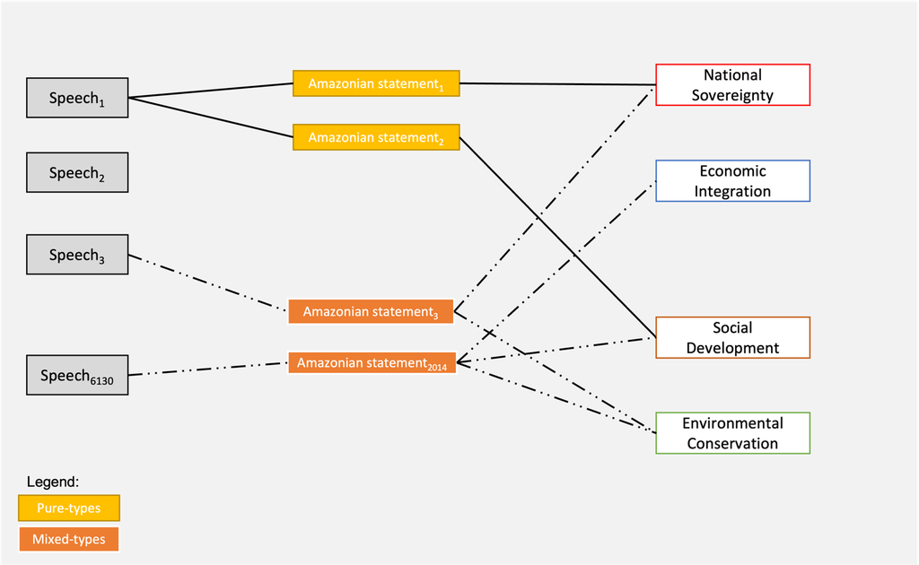

Figure 1: Operationalization of Problem-constructions

With the codebook in hand, each one of the authors, separately, hand-coded the same set of 1007 randomly selected Amazonian statements. This amount refers to 50% of all the Amazon Statements identified. We chose to hand code half of the observations because since there are several nuances in discourse in how presidents talk about the amazon in time and as a problem, we conservatively code a relatively large training set for the subsequent automated machine learning. As well, this allows a robust validation set to verify the models. Still, automating the coding of half of the observations saved the authors over one month of work in comparison to manual coding. Intercoder agreement for each of the four main categories was 85%, on average. For each non-matching coded observation, the co-authors discussed and sorted their disagreements. The manually coded data is then randomly divided into a training set, containing 80% of the hand-coded observations (806 observations), and a validation set, containing the remaining 20% of the hand-coded data (201 observations).

We chose to employ a support-vector machine (SVM) algorithm to label texts, that is, a non- probabilistic linear classifier that classifies documents by assigning points in mapped space to maximize the gap between binary categories [Meyer et al. (2021); Noble (2006)] . The SVM model is first trained using the hand coded training set and then employed to classify observations in the hand coded validation set. The trained SVM model was, on average 82%, accurate in classifying observations in the validation set before being tuned. After the SVM model is tuned, we use the model to automatically code the remaining 1007 Amazonian statements. The final dataset for analysis, excluding false positive matches, contains 1895 coded Amazonian statements. Finally, we extract locations for all speeches in the data. These locations represent the Brazilian state in which certain speech was given or an international country.

## 3.2 Analysis and Limitations

To analyze our data, we first present a series of different plots on proportions of Amazonian statements and problem-constructions over time and by presidents. We control proportions for factors that might affect the incidence of the Amazon in speeches and portray both real and controlled curves. To test whether different problem constructions change according to location, we run a multinomial logit model in which different problem constructions (as categories) are the dependent variable and location is the independent variable. Multinomial logit is an appropriate method for modeling data in which the dependent variable of interest is categorical, unordered, and has many categories, as is our case (Kwak and Alan Clayton-Matthews 2002). In our model, we also control for annual deforestation rates, annual inflation rates, and election years in the model. We interpret the plots and model considering multiple Amazon related events and policies over the last 30 years, as well as their correlations with different presidents and locations, while embedding problem-construction in contemporary happenings.

This approach also comes with limitations. Our codebook is developed using specific Amazon-related vocabulary. For example, a statement will be coded as economic integration if it is meaningful support to the tax-free zone of Manaus or a Dam in the Amazon. However, the economy is generally a topic that presidents speak about. Hence, the high incidence of economic integration in Amazonian statements can also be related to the higher importance of this problem-construction in Brazil in time. Moreover, we classify statements as Amazonian based on a dictionary composed of a single lexicon stem: “amazon”. We chose to do so knowing that a few speeches about the Amazon might not contain the lexicon “Amazon”, for example, when the president says, “the forest” or “deforestation”. Hence, we might be missing statements about Amazon that do not refer to it. However, we consider this safer as we cannot be sure that mentions of the forest or deforestation do not correspond to other biomes such as the Cerrado or the Mata Atlantica. Nevertheless, our dataset covers only what is considered an official remark. Presidents, though, give interviews, appear in debates, talk at campaign rallies, and more recently started to appear on social media. Problem- construction within presidential discourse, thus, also happens in different sites for which we do not account for in this paper.

# 4 The Amazon in Presidential Speeches

## 4.1 The rises and falls of the Amazon as a topic in presidential speeches

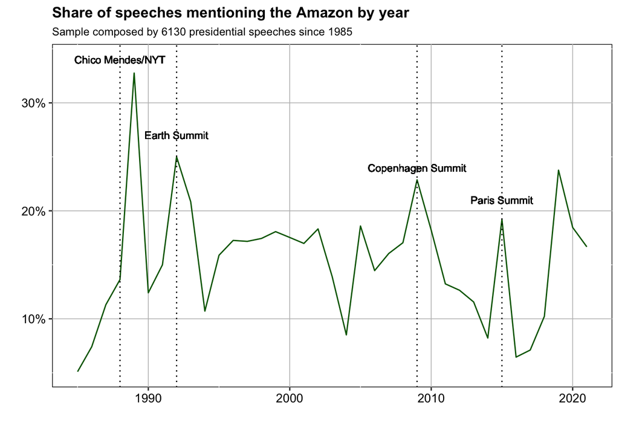

In 1990 the Amazon appeared in 12% of all speeches and, by 1992, this increased to 25% of all speeches. The 1992 Earth Summit, held in Brazil, and prepared by various state and non-state actors in the region, brought international attention to environmental topics. One of the big announcements, for example, was the consolidation of the first transnational partnership for the Amazon, the G7 Pilot Programme, which brought a high number of financial resources to the region for public policy implementation (Capobianco 2021). Throughout the 1990s and 2000s, however, the Amazon appeared, on average, on 15% of all speeches. By the end of the 2000s, we see another spike in the Amazon appearing in official speeches. This spike coincides with the 2009 Copenhagen Summit as well as the steepest decrease in deforestation rates since data is available. Lula led the delegation to Copenhagen with a self-image of “we do not promise, we deliver” when the stakes about climate change were high (Franchini and Viola 2019).

From 2010 to 2018, with the exception of 2015, we see a general decrease in mentions of the Amazon in all official presidential speeches. The Amazon appeared in 8% of official speeches in 2014. In 2015, the Amazon appeared in 19% of speeches. This spike coincides with the Paris summit which became a key turn in climate politics after the failures of Copenhagen. Disagreements related to the priority of environmental preservation over economic development, most notably in the case of Itaipu Dam, led the environmental minister Marina Silva to resign and run for the presidency on her agenda in 2010. These are also the years when Brazil entered a long period of political and economic instability, which led to the impeachment of Dilma Roussef. Brazil went to the Paris Summit with deforestation numbers slightly higher than Copenhagen, and a perception that there was a turn towards less conservation since Marina Silva left the government and the 2011 New Forest Code was approved. By 2016, however, mentions of the Amazon in official speeches went down to 6%, the lowest share since 1985.

## 4.2 How has the Amazon been constructed as a problem?

### Pure-type problem constructions

We conceptualize four pure problem constructions: sovereignty, economic integration, social development, and conservation. At the level of the speech, though, presidents might mix multiple problem construction in an Amazonian statement. Pure problem constructions dominate, average around 56% of all amazonian statements across time. As above, we observe a strong variation over time for most of these constructions. Figure 3, below, illustrates the share of each pure type in time.

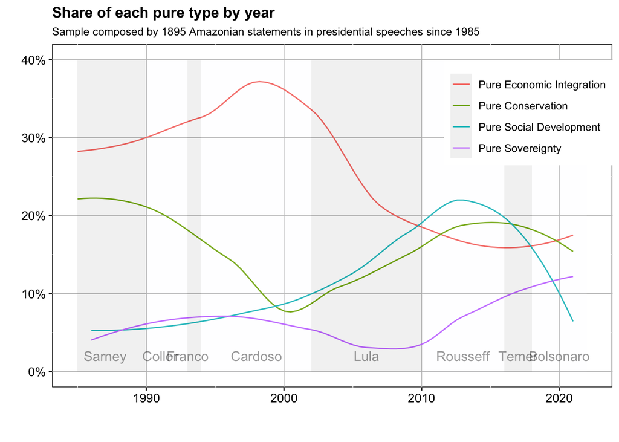

The plot reveals several trends. Pure economic integration constructions, for example, dominated constructions from 1985 to the late 2000s. This is especially pertinent during the Cardoso administration as the Amazon was constructed overwhelmingly as an issue of economic integration. This changed during the Lula presidency. During his terms, constructions of the Amazon purely as an economic issue decreased in discourse while constructions of the Amazon as issues of pure conservation as well as of pure social development increased. These constructions surpassed economic integration around 2010. These trends in discourse continued during the Rousseff administration. Capobianco (2021), for example, argues that the unprecedented decrease in deforestation we observed from 2004 to 2012 was a product of an increase in the perception of stronger federal policies and presence in the Amazon region, which in turn engendered a perception of higher risk of being caught and fined for deforestation. A higher incidence of the Amazon, as a topic in overall presidential speeches, generates a perception that more attention is being país to the Amazon from the top while the shift from constructing the Amazon as an issue of economic integration to an issue of environmental conservation generates a perception that illegal deforestation will be increasingly monitored.

From the mid-2010s onwards, we start to see a reverse of this trend: economic integration problem construction increases while conservation and social development constructions decrease instead. Interestingly, sovereignty starts to increase steadily from 2010 onwards and by 2019 sovereignty constructions surpass social development. construction. Figure 3 also highlights that while the reversal precedes the mandate of President Bolsonaro, it was with him and his dismantling of social and environmental policies that sovereignty constructions reached their peak since 1985.

### Mixed-type problem constructions

Although presidents prefer pure problem-constructions, presidents also construct the Amazon as multifaceted issues. Mixed-type problem constructions in discourse offer more complex understandings of the Amazon as an issue. Constructing the Amazon as multiple issues averages at 18% of all constructions for presidents. While there is some variation in time and some mixed-types rarely appear, we focus our discussion on those mixed-types with higher incidence. Figure 4, below, displays the average mixed-types in time.

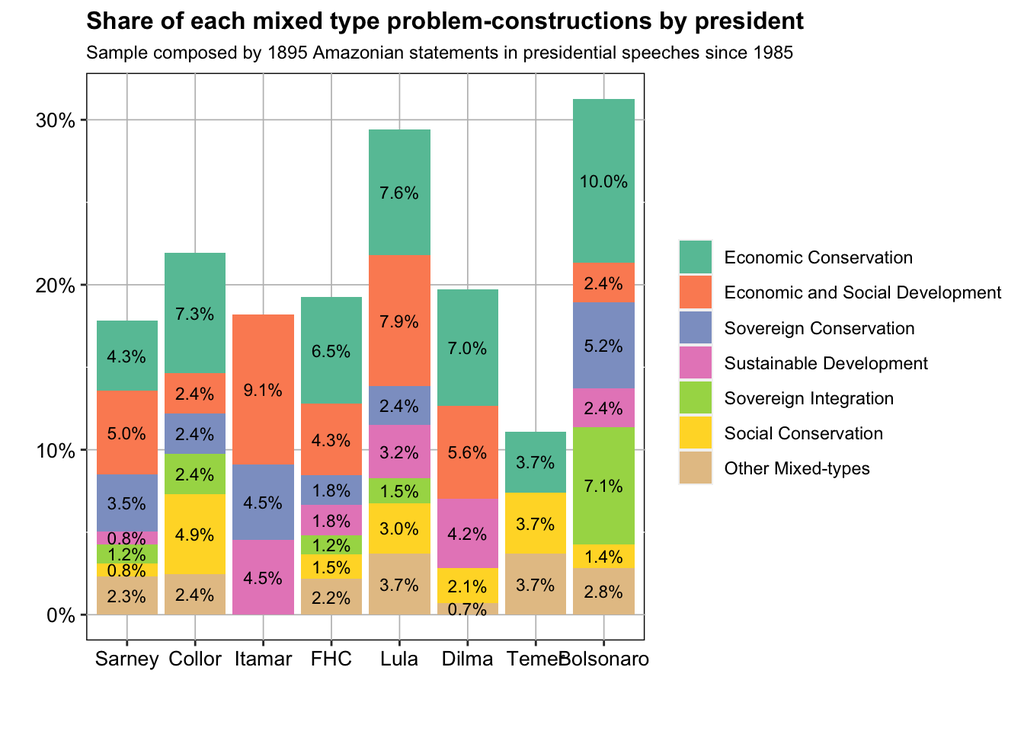

## 4.3 The Amazonian multi-level game, boasting policy outside and talking to people inside

Problem constructions depend on where presidents speak. To facilitate analysis and make sense of locations, we divide locations into Amazonian states (i.e. all the Brazilian states in which the Amazon biome is present), non Amazonian states (other Brazilian states), Brasilia (the capital of Brazil where the federal government is located), Amazonian countries (neighboring countries where the biome is present), and international countries (countries outside of Brazil). To analyze the relationship between location and problem construction, we run a multinomial regression. Our dependent variable is problem-constructions (categorical), while our main dependent variable is location (categorical). The reference category for the multinomial model is, thus, environmental conservation in international states. We control for deforestation rates (numerical), inflation (numerical), and election year. Since the model accounts for both mixed and pure-type Amazonian constructions, and this makes for a large table, we focus the analysis on pure-types to facilitate visualization (see full regression table in appendix).

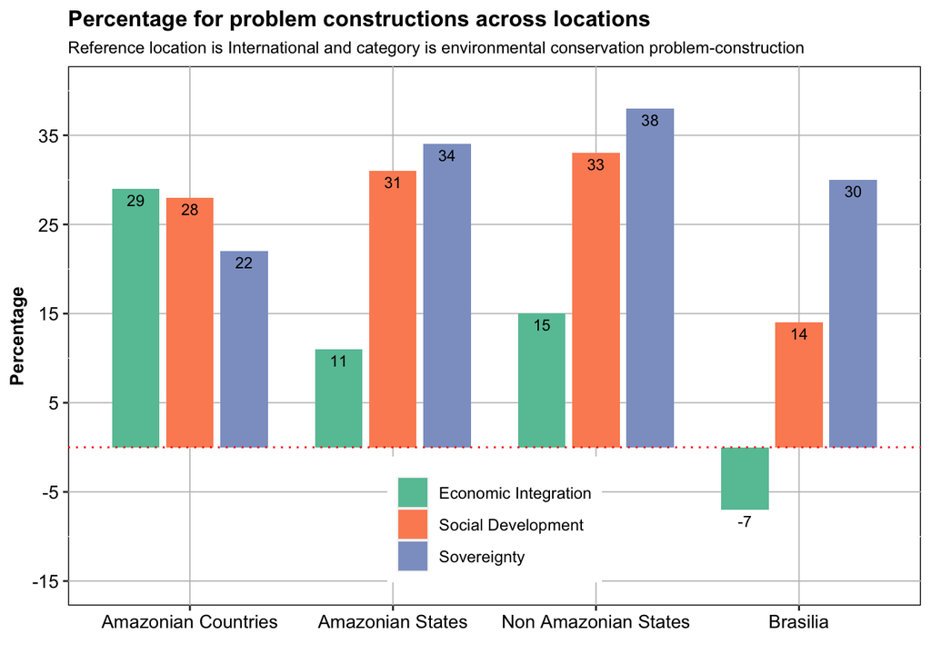

Along these lines, constructing the Amazon as an issue of social development takes place, overwhelmingly, within Brazil or other Amazonian countries. Presidents are at least 14% more likely to construct the Amazon as an issue of social development in these locations than internationally. The same is true for sovereignty, whereas constructing the Amazon as an issue of sovereignty takes place within Brazil or in neighboring Amazonian countries. Notice, as well, how Amazonian constructions within Amazonia states and non Amazonian states are strikingly similar. This indicates that presidents are consistent when constructing the Amazon locally across the federation when outside of Brasilia.

The Amazon, as a region and a forest, has historically been the topic of international, national, supranational, and local debates, negotiation and policies. Our findings show that how the amazon is constructed as a problem varies across these levels. This implies not only that audiences’ priorities in each setting change, but that which policies are appropriate to solve the “Amazon issue” could differ as well. The multi-level game entails that conservation might be a desirable construction when speaking internationally about the Amazon, or in Brasilia, but not for local electorates. Local electorates who, ultimately, elect presidents.

This multi-level game leads to different policies being negotiated, often simultaneously, so that the overlap at the interplay between the levels is maximized. Take, for once, how the Brazilian government successfully funded domestic public policy with international support since the 1990s (e.g. 1992 Programa Piloto para Proteção das Florestas Tropicais), by creating a federal fund for the protected areas (e.g. 2001 Amazon Region Protected Areas program), and by assuring international funds with the establishment of the Amazon Fund in 2008 which provided over USD1 billion for environmental conservation in the Amazon (Silva-Muller and Faul 2022). Still, this does not mean, though, that the national agenda of economic integration or social development was not pursued. During the same time rural credit offered to local agricultural producers in Amazonian states, went up from 500 million reais a year in 1999 to over 4 billion a year by 2012 (Capobianco 2021). Nowadays, it has reached unprecedented levels.

# 5 Discussion and Conclusion

The Amazon frontier as an analytic category can help us shed light on the differences we identify between the discourse in Amazonian States compared to Brasilia and other States. Whereas presidential discourses at the top matter to define and justify public policy (Zarefsky 2004), presidents shape their discourses according to who their audience might be and what “they want to hear”. If presidents promote an agenda of economic and social development within Brazil that diverges from the one the president promotes outside of Brazil, the question for democracy becomes to what extent the implemented agenda responds to domestic versus international demands. Or, as Putnam (1988) puts it, what’s the actual overlap between the international and domestic overlap. The domestic policies and transnational support that led to the decrease in deforestation from 2004 to 2012 happened concurrently with a period of strong economic growth and social development in Brazil and worldwide. With the strengthening of environmentalism and indigenous participation in politics in the late 1980s and 1990s, we can interpret the fall of economic integration and the rise of social and conservation problem-constructions as a new relationship between granting local livelihoods their rights and economic exploitation.

While unprecedented, this new balance was not long-standing. Democratic decay is slow, and the embryo of Bolsonaro’s Amazonian discourse was breeding half a decade before he took office. We observe the decrease in conservation-related statements in the mid-2010s, and the soft increase of sovereignty both pure and in mixes already late 2000s (figure 3). The hard increase in sovereignty comes in the early 2010s. As we conceptualize and operationalize sovereignty as boundary-making vis- à-vis internal and external perceived threats to the Amazon, we interpret this increase as attacks on indigenous and traditional populations. On the policy side, the Itaipu Dam in the late 2000s and the 2011 Forest code is seen as a turning point: political opposition to conservation got particularly organized and managed to lobby the executive and conquer this policy wins, which were largely opposed by environmentalists. The political forces in Brazilian democracy that drive these changes in problem-construction were long in the making, as the earlier and softer shifts in discourse suggest. Bolsonaro’s problem-construction is the strongest form of this shift.

In sum, this paper investigates how the Amazon has been constructed as a problem in Brazilian presidential speeches since 1985. Our findings show that these constructions are not monolithic within governments, in time, or across different locations. Conceptually, this contributes to understanding the social construction of the Amazon in discourses and how these might relate to outcomes such as policies and environmental outcomes. Empirically, we build the first comprehensive overview of the Amazon in presidential discourse. Given the importance of discursive problem-construction within democracies to legitimize ways of thinking and acting towards the environment while affecting decisions to deforest, or not, at the local level, further research on the relationship between the social construction of the Amazon, one of the worlds most important standing ecosystems, and its effects on environmental outcomes is pressing.

# References

[^1]: Both co-authors contributed equally to the article; names are ordered alphabetically. Both of them are PhD candidates at The Geneva Graduate Institute. Livio is a PhD Candidate in Anthropology and Sociology at the Geneva Graduate Instituteis affiliated to the Albert Hirschman Centre on Democracy. Henrique is a PhD Candidate in International Relations and Political Sciences at the Geneva Graduate Institute affiliated to the Centre for International Environmental Studies.